# R Notebook

Steps Performed:

Understanding the data. Finding missing values.

Separate categorical and numerical. univariate analysis. checking the distribution of each variable in numerical data. checking the correlation for numerical data. checking the frequency for categorical data.

Household_ID -> Unique identifier for each household. Vehicle -> Unique identifier for each vehicle within a household. Calendar_Year -> Calendar year during which vehicle was insured ,years:2005,2006,2007. Model_Year -> Model year of vehicle ,29levels->1981 to 2009 Blind_Make -> Vehicle make(example: ACME, coded A) Blind_Model -> Vehicle model(example: ACME Roadster, coded A.1) Blind_Submodel -> Vehicle submodel (example: ACME Roadster LS, coded A.1.1) e.g. no suffix after the model name–submodel is coded as 0.

Target:Claim_Amount The goal of this competition is to predict Bodily Injury Liability Insurance claim payments based on the characteristics of the insured’s vehicle.

So it is a Regression Problem.

```r
Path="G:\\Old_drive\\Projects\\Allstate_Claim_Prediction_Challenge"
setwd(Path) #setting working directory
```

```
The working directory was changed to G:/Old_drive/Projects/Allstate_Claim_Prediction_Challenge inside a notebook chunk. The working directory will be reset when the chunk is finished running. Use the knitr root.dir option in the setup chunk to change the the working directory for notebook chunks.
```

```r
getwd()
```

```
[1] "G:/Old_drive/Projects/Allstate_Claim_Prediction_Challenge"
```

```r
data <- read.csv("data/train_1L.csv") #Reading the data
attach(data)     #attach the dataset ,we can call the variables directly without dataframe name.
names(data)   #column names of the data
```

```
 [1] "Row_ID"         "Household_ID"   "Vehicle"        "Calendar_Year"  "Model_Year"
 [6] "Blind_Make"     "Blind_Model"    "Blind_Submodel" "Cat1"           "Cat2"
[11] "Cat3"           "Cat4"           "Cat5"           "Cat6"           "Cat7"
[16] "Cat8"           "Cat9"           "Cat10"          "Cat11"          "Cat12"
[21] "OrdCat"         "Var1"           "Var2"           "Var3"           "Var4"
[26] "Var5"           "Var6"           "Var7"           "Var8"           "NVCat"
[31] "NVVar1"         "NVVar2"         "NVVar3"         "NVVar4"         "Claim_Amount"
```

```r
str(data) #structure of the data
```

```
'data.frame':   100000 obs. of  35 variables:
 $ Row_ID        : int  13117732 6046907 13103659 11947842 750049 2568773 7805023 6272873 869856 11580907 ...
 $ Household_ID  : int  7496621 4072191 7488069 6978037 536106 1879710 4973724 4142805 589272 6840246 ...
 $ Vehicle       : int  1 1 2 2 1 1 1 1 1 4 ...
 $ Calendar_Year : int  2005 2005 2005 2007 2006 2006 2005 2005 2007 2005 ...
 $ Model_Year    : int  2001 1999 1987 1996 1999 1983 1999 1995 1999 2001 ...
 $ Blind_Make    : Factor w/ 62 levels "?","AC","AD",..: 55 55 9 52 32 61 61 52 61 32 ...
 $ Blind_Model   : Factor w/ 992 levels "?","AC.1","AC.2",..: 897 888 109 836 467 967 976 835 970 467 ...
 $ Blind_Submodel: Factor w/ 2002 levels "?","AC.1.1","AC.1.2",..: 1754 1696 149 1603 865 1964 1982 1597 1972 865 ...
 $ Cat1          : Factor w/ 11 levels "?","A","B","C",..: 6 3 5 3 5 6 7 7 7 5 ...
 $ Cat2          : Factor w/ 4 levels "?","A","B","C": 4 3 1 1 2 1 4 1 4 2 ...
 $ Cat3          : Factor w/ 7 levels "?","A","B","C",..: 3 2 4 2 2 4 2 2 2 2 ...
 $ Cat4          : Factor w/ 4 levels "?","A","B","C": 2 2 1 2 1 2 4 3 4 1 ...
 $ Cat5          : Factor w/ 4 levels "?","A","B","C": 2 2 1 2 1 2 2 2 2 1 ...
 $ Cat6          : Factor w/ 6 levels "?","B","C","D",..: 2 3 3 3 4 2 3 3 4 4 ...
```

[output cut: 21 more lines]

checking the datatypes

```r
summary(data)
```

```
     Row_ID          Household_ID        Vehicle      Calendar_Year    Model_Year     Blind_Make
 Min.   :     530   Min.   :    286   Min.   : 1.00   Min.   :2005   Min.   :1981   K      :12678
 1st Qu.: 3294176   1st Qu.:2184288   1st Qu.: 1.00   1st Qu.:2005   1st Qu.:1996   AJ     :11822
 Median : 6587619   Median :4255648   Median : 2.00   Median :2006   Median :2000   BW     : 9653
 Mean   : 6592954   Mean   :4128178   Mean   : 1.89   Mean   :2006   Mean   :1999   AU     : 8139
 3rd Qu.: 9885830   3rd Qu.:6280718   3rd Qu.: 2.00   3rd Qu.:2007   3rd Qu.:2003   Y      : 6399
 Max.   :13184252   Max.   :7542079   Max.   :17.00   Max.   :2007   Max.   :2008   X      : 6056
                                                                                    (Other):45253
  Blind_Model    Blind_Submodel       Cat1       Cat2      Cat3      Cat4      Cat5      Cat6
 K.7    : 4550   K.7.3  : 1273   B      :30262   ?:36897   ?:   24   ?:42780   ?:42820   ?:  213
 AU.14  : 2364   AU.14.1: 1108   I      :20094   A:16694   A:56650   A:43354   A:50506   B:32573
 X.45   : 2211   AU.14.0: 1092   D      :18898   B: 1745   B:17255   B: 2793   B:  601   C:27537
 W.16   : 1760   AU.11.3: 1079   F      : 9922   C:44664   C: 9746   C:11073   C: 6073   D:27457
 AU.11  : 1588   AU.58.0: 1065   G      : 6096             D: 3046                       E: 8863
 BO.38  : 1474   W.16.3 : 1014   A      : 5811             E: 6724                       F: 3357
 (Other):86053   (Other):93369   (Other): 8917             F: 6555
 Cat7      Cat8      Cat9      Cat10     Cat11     Cat12         OrdCat           Var1
 ?:54386   ?:   24   A:17794   ?:   26   ?:  264    :  241   4      :45111   Min.   :-2.578222
 A: 8139   A:65486   B:82206   A:65107   A:53031   A:   17   2      :31311   1st Qu.:-0.665897
 B: 1753   B:27748             B:30018   B:23800   B:33116   5      :22533   Median :-0.312358
 C:34811   C: 6742             C: 4849   C: 8330   C:27402   3      :  739   Mean   :-0.006898
 D:  911                                 D: 2324   D:26795   6      :  119   3rd Qu.: 0.442930
                                         E: 6291   E: 8950   1      :  110   Max.   : 5.143392
                                         F: 5960   F: 3479   (Other):   77
      Var2               Var3               Var4              Var5                Var6
 Min.   :-2.45881   Min.   :-2.74405   Min.   :-2.4575   Min.   :-3.350344   Min.   :-2.37666
 1st Qu.:-0.79886   1st Qu.:-0.86969   1st Qu.:-0.7830   1st Qu.:-0.662235   1st Qu.:-0.68759
 Median :-0.12451   Median :-0.19862   Median :-0.1065   Median :-0.115098   Median :-0.23141
 Mean   :-0.06242   Mean   :-0.02026   Mean   :-0.0521   Mean   : 0.005725   Mean   :-0.03567
 3rd Qu.: 0.48068   3rd Qu.: 0.72700   3rd Qu.: 0.4855   3rd Qu.: 0.533140   3rd Qu.: 0.50668
 Max.   : 7.20694   Max.   : 5.56332   Max.   : 6.9804   Max.   : 4.006272   Max.   : 4.58429

      Var7               Var8              NVCat           NVVar1             NVVar2
 Min.   :-2.28699   Min.   :-2.16304   M      :43629   Min.   :-0.23153   Min.   :-0.26612
 1st Qu.:-0.89849   1st Qu.:-0.65177   O      :25740   1st Qu.:-0.23153   1st Qu.:-0.26612
 Median :-0.45613   Median :-0.25631   N      :10192   Median :-0.23153   Median :-0.26612
 Mean   :-0.01966   Mean   :-0.05564   L      : 6199   Mean   : 0.01569   Mean   : 0.01787
 3rd Qu.: 0.82178   3rd Qu.: 0.34153   J      : 4271   3rd Qu.:-0.23153   3rd Qu.:-0.26612
 Max.   : 3.90597   Max.   :34.33289   E      : 3077   Max.   : 6.62711   Max.   : 8.88308
                                       (Other): 6892
     NVVar3            NVVar4          Claim_Amount
 Min.   :-0.2723   Min.   :-0.25142   Min.   :   0.000
 1st Qu.:-0.2723   1st Qu.:-0.25142   1st Qu.:   0.000
 Median :-0.2723   Median :-0.25142   Median :   0.000
 Mean   : 0.0113   Mean   : 0.02298   Mean   :   1.382
 3rd Qu.:-0.2723   3rd Qu.:-0.25142   3rd Qu.:   0.000
 Max.   : 8.6911   Max.   : 6.38880   Max.   :3128.622
```

missing values(?)

Cat2 has 36897 Cat3 has 24 Cat4 has 42780 Cat5 has 42820 Cat6 has 213 Cat7 has 54386 Cat8 has 24 Cat10 has 26 Cat11 has 264 Cat12(blank) 241

Target variable:

```r
#Claim_Amount
#table(Claim_Amount)   #Claim_Amount frequency
prop.table(table(Claim_Amount)) #Claim_Amount frequency percentage.
```

[output not shown]

[output cut: 106 more lines]

[output not shown]

99286 rows has 0’s. which contains 99% data.

distribution of target variable

```r
# Density and rug
d <- density(Claim_Amount)
plot(d, type="n", main="Claim_Amount")
polygon(d, col="lightgray", border="gray")
```

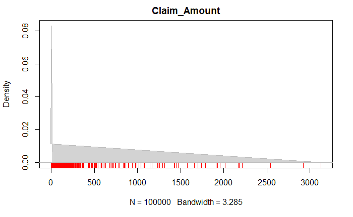

```r
rug(Claim_Amount, col="red")
```

high concentrationof data is at 0.and gets sprased while the claim amount increases.

# plots

Distribution of categorical and numerical variables

```r
source(paste0(Path,"/scripts/utilities/plots_func.R"))  #reading plots function
plotsfunc(data,"G:\\Old_drive\\Projects\\Allstate_Claim_Prediction_Challenge\\plots") #plots will save into the path specified
```

Model-year=>left skewed. var1 ,var2, var3 ,var4 ,var6 ,var7,var8 => right skewed.(long tail)

most the variables has outliers.

Seperate numerical and Categorical data

```r
factors <- sapply(data, is.factor) #checking the variable is a factor
vars_categ <- data[, factors]     #taking only factor variables
names(vars_categ)
```

```
 [1] "Blind_Make"     "Blind_Model"    "Blind_Submodel" "Cat1"           "Cat2"           "Cat3"           "Cat4"
 [8] "Cat5"           "Cat6"           "Cat7"           "Cat8"           "Cat9"           "Cat10"          "Cat11"
[15] "Cat12"          "OrdCat"         "NVCat"
```

```r
vars_numeric <- data[,!factors]   #taking only numerical variables
names(vars_numeric)
```

```
 [1] "Row_ID"        "Household_ID"  "Vehicle"       "Calendar_Year" "Model_Year"    "Var1"          "Var2"
 [8] "Var3"          "Var4"          "Var5"          "Var6"          "Var7"          "Var8"          "NVVar1"
[15] "NVVar2"        "NVVar3"        "NVVar4"        "Claim_Amount"
```

17-categorical 18-Numerical

```r
length(unique(Household_ID)) #unique Household_ID
```

```
[1] 98679
```

```r
length(unique(Row_ID)) #unique Row_ID
```

```
[1] 100000
```

Row id is unique. but household id is dupicated.

```r
#Removing rowId
vars_numeric <- vars_numeric[, -which(names(vars_numeric) %in% c("Row_ID"))]
```

```r
length(Household_ID[duplicated(Household_ID)]) #duplicated records
```

```
[1] 1321
```

```r
source(paste0(Path,"/scripts/utilities/correlation.R"))  #reading correlation
corFun(vars_numeric)
```

|  | var1 | var2 | correlation |
| --- | --- | --- | --- |
| 60 | Var1 | Var3 | 0.7439468 |
| 62 | Var1 | Var5 | 0.9056517 |
| 63 | Var1 | Var6 | 0.7770269 |
| 72 | Var2 | Var4 | 0.9826592 |
| 74 | Var2 | Var6 | 0.7705317 |
| 83 | Var3 | Var5 | 0.7840115 |
| 84 | Var3 | Var6 | 0.8258885 |
| 93 | Var4 | Var6 | 0.7845325 |
| 101 | Var5 | Var6 | 0.7490182 |
| 109 | Var6 | Var7 | 0.8014416 |

Saving Raw numeric and categorical data

```r
write.csv(vars_numeric,paste0(Path,'/data_for_models/raw_numerical.csv'),row.names = F)
write.csv(vars_categ,paste0(Path,'/data_for_models/raw_categorical.csv'),row.names = F)
```